# Problem Set 4

Author

Kimball Weeks

Published

November 20, 2026

**GitHub repo:** https://github.com/kimballw1/ec422_ps4_KimballWeeks

```r
library(pacman)
p_load(tidyverse, fpp3, BVAR)
```

## ARIMA vs. ETS

### 2.1 The Data

```r
liquor_raw <- read_csv(
  "data/MRTSSM4453USN.csv",
  na = ".",
  col_types = cols(
    observation_date = col_date(format = "%Y-%m-%d"),
    MRTSSM4453USN = col_double()
  )
)

liquor <- liquor_raw |>
  transmute(Month = yearmonth(observation_date), sales = MRTSSM4453USN) |>
  as_tsibble(index = Month) |>
  filter(Month <= yearmonth("2019 Dec"))

has_gaps(liquor)
```

```
# A tibble: 1 × 1
  .gaps
  <lgl>
1 FALSE
```

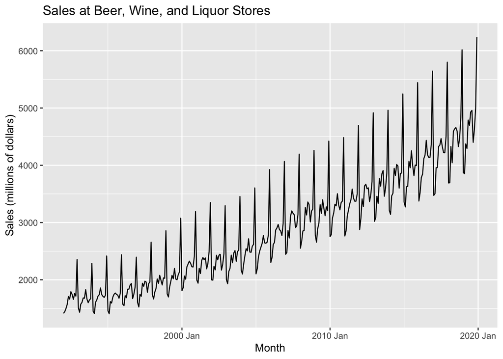

```r
autoplot(liquor, sales) +
  labs(title = "Sales at Beer, Wine, and Liquor Stores",
       x = "Month",
       y = "Sales (millions of dollars)")
```

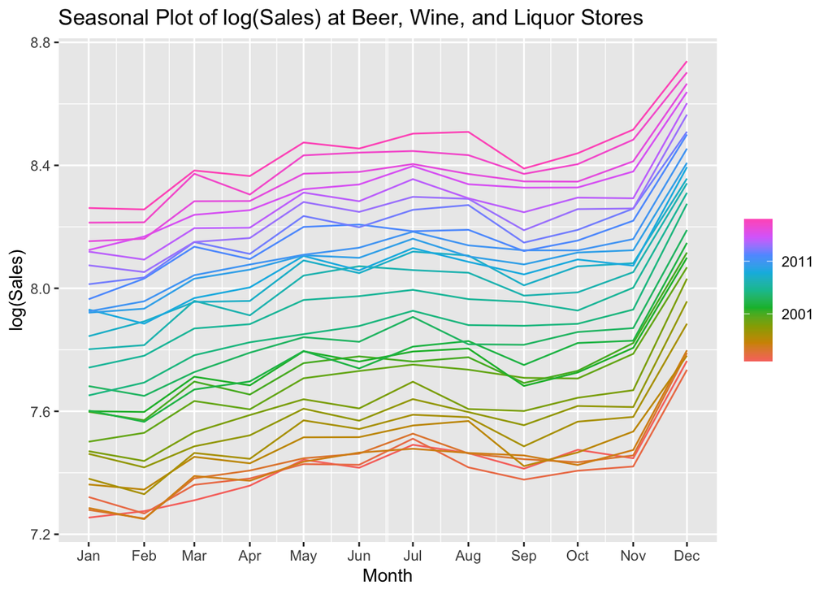

```r
liquor |>
  gg_season(log(sales)) +
  labs(title = "Seasonal Plot of log(Sales) at Beer, Wine, and Liquor Stores",
       x = "Month",
       y = "log(Sales)")
```

Sales trend steadily upward over the whole sample, from about $1.4 billion a month in early 1992 to over $6 billion in December 2019. There are no big breaks in the trend. The seasonal pattern is very strong and repeats every year. December is by far the highest month and January and February are the lowest.

In the level plot, the seasonal swings clearly get bigger as the series grows. That means the seasonality is multiplicative. Taking logs turns that into an additive pattern.

### 2.2 Fit Both Models

```r
liquor_fit <- liquor |>
  model(arima = ARIMA(log(sales)),
        ets   = ETS(log(sales)))

liquor_fit |> select(arima) |> report()
```

```
Series: sales
Model: ARIMA(1,0,2)(2,1,1)[12] w/ drift
Transformation: log(sales)

Coefficients:
         ar1      ma1     ma2    sar1     sar2     sma1  constant
      0.8948  -0.7374  0.2477  0.3679  -0.2334  -0.8845    0.0036
s.e.  0.0355   0.0697  0.0623  0.0668   0.0665   0.0468    0.0001

sigma^2 estimated as 0.0005469:  log likelihood=752.43
AIC=-1488.85   AICc=-1488.4   BIC=-1458.61
```

```r
liquor_fit |> select(ets) |> report()
```

```
Series: sales
Model: ETS(A,A,A)
Transformation: log(sales)
  Smoothing parameters:
    alpha = 0.3296099
    beta  = 0.007560263
    gamma = 0.0001765132

  Initial states:
     l[0]         b[0]      s[0]      s[-1]        s[-2]       s[-3]      s[-4]
 7.412219 0.0007608238 0.3263441 0.03153301 -0.004849389 -0.03530501 0.02512163
      s[-5]      s[-6]      s[-7]       s[-8]      s[-9]     s[-10]     s[-11]
 0.05558624 0.01219515 0.02503206 -0.06088935 -0.0607952 -0.1578065 -0.1561667

  sigma^2:  7e-04

      AIC      AICc       BIC
-489.1517 -487.2272 -424.2608
```

fable chose an **ARIMA(1,0,2)(2,1,1)[12] with drift** and an **ETS(A,A,A)**.

The ARIMA has d = 0 and D = 1, so the series was seasonally differenced once and not regularly differenced.

For the ETS All three are additive. The errors are added to the forecast, the trend is a linear (not damped) trend, and the seasonal effects are added on.

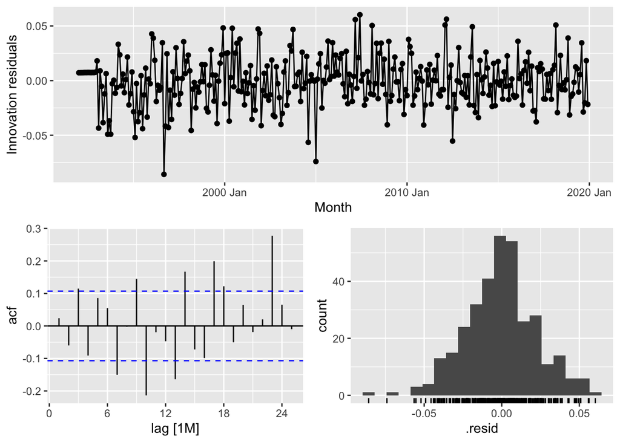

```r
liquor_fit |> select(arima) |> gg_tsresiduals()
```

```r
liquor_fit |>
  select(arima) |>
  augment() |>
  features(.innov, ljung_box, lag = 24, dof = 6)
```

```
# A tibble: 1 × 3
  .model lb_stat lb_pvalue
  <chr>    <dbl>     <dbl>
1 arima     120.         0
```

I set dof = 6 because the ARIMA has p + q + P + Q = 1 + 2 + 2 + 1 = 6 estimated AR and MA coefficients.

The residuals do not look like white noise. The Ljung–Box statistic is about 120 with a p-value near zero, so I reject that the first 24 autocorrelations are all zero. The ACF has several significant spikes, the largest at lag 23, so there is structure the model hasn’t captured.

### 2.3 The Horse Race

The TS-CV takes over 10 minutes, so I load the saved fits from my script.

```r
liquor_cv_fit <- readRDS("results/liquor_cv_fit.rds")

nrow(liquor_cv_fit)
```

```
[1] 216
```

The TS-CV uses **216 forecast origins**, with training samples ending from December 2001 through November 2019.

```r
liquor_cv_fc <- liquor_cv_fit |>
  forecast(h = 1)

range(liquor_cv_fc$Month)
```

```
<yearmonth[2]>
[1] "2002 Jan" "2019 Dec"
```

```r
liquor_cv_fc |>
  accuracy(liquor, measures = list(RMSE = RMSE, MAE = MAE)) |>
  knitr::kable(digits = 2)
```

| .model | .type | RMSE | MAE |
| --- | --- | --- | --- |
| arima | Test | 81.43 | 65.65 |
| ets | Test | 94.35 | 72.31 |
| snaive | Test | 161.26 | 136.63 |

The first forecast is for **January 2002** and the last is for **December 2019**. ARIMA is the most accurate (RMSE about 81, MAE about 66), ETS is second, and the seasonal random walk is worst. RMSE and MAE agree on the ranking.

### 2.4 Are the Differences Significant?

```r
liquor_errs <- liquor_cv_fc |>
  as_tibble() |>
  left_join(as_tibble(liquor) |> select(Month, actual = sales),
            by = "Month") |>
  mutate(e = actual - .mean) |>
  select(Month, .model, e) |>
  pivot_wider(names_from = .model, values_from = e)

# ARIMA vs. ETS
dm_ets <- forecast::dm.test(liquor_errs$arima, liquor_errs$ets, h = 1, power = 2)

# ARIMA vs. seasonal random walk
dm_snaive <- forecast::dm.test(liquor_errs$arima, liquor_errs$snaive, h = 1, power = 2)

tibble(Comparison = c("ARIMA vs. ETS", "ARIMA vs. SNAIVE"),
       `DM statistic` = c(dm_ets$statistic, dm_snaive$statistic),
       `p-value` = c(dm_ets$p.value, dm_snaive$p.value)) |>
  knitr::kable(digits = 4)
```

| Comparison | DM statistic | p-value |
| --- | --- | --- |
| ARIMA vs. ETS | -2.9062 | 0.004 |
| ARIMA vs. SNAIVE | -10.7549 | 0.000 |

Both DM statistics are negative, so ARIMA has smaller squared errors in each comparison. ARIMA significantly beats ETS (DM = −2.91, p = 0.004) and the seasonal random walk (DM = −10.76, p roughly 0). I would use ARIMA: it wins on both metrics and the differences are significant.

## Forecast Combination

```r
liquor_combo_fc <- liquor_cv_fit |>
  mutate(combo = (arima + ets) / 2) |>
  forecast(h = 1)

liquor_combo_fc |>
  accuracy(liquor, measures = list(RMSE = RMSE, MAE = MAE)) |>
  knitr::kable(digits = 2)
```

| .model | .type | RMSE | MAE |
| --- | --- | --- | --- |
| arima | Test | 81.43 | 65.65 |
| combo | Test | 85.19 | 66.77 |
| ets | Test | 94.35 | 72.31 |
| snaive | Test | 161.26 | 136.63 |

The combination falls between its two parts. It beats ETS but is worse than ARIMA on both RMSE (85.2) and MAE (66.8).

```r
cor(liquor_errs$arima, liquor_errs$ets)
```

```
[1] 0.8782932
```

The ARIMA and ETS errors have a correlation of 0.88, so the models mostly miss in the same months and averaging cancels little error. Combining helps most when models are similarly accurate and their errors are less correlated, which isn’t the case here.

## VAR vs. BVAR

### 4.1 The Data

```r
qd_raw <- read_csv("data/fredqd_2026-09.csv", show_col_types = FALSE) |>
  slice(-(1:2))

growth <- function(x) 100 * difference(log(x))

qd <- qd_raw |>
  mutate(date = as.Date(sasdate, "%m/%d/%Y")) |>
  transmute(date,
            gdp    = growth(GDPC1),         # real GDP
            cons   = growth(PCECC96),       # real consumption
            inv    = growth(GPDIC1),        # real investment
            emp    = growth(PAYEMS),        # payroll employment
            infl   = growth(GDPCTPI),       # GDP price index
            unrate = difference(UNRATE),    # unemployment rate
            ffr    = difference(FEDFUNDS),  # federal funds rate
            gs10   = difference(GS10)) |>   # 10-year Treasury yield
  filter(date >= as.Date("1960-03-01"), date <= as.Date("2019-12-01"))

y <- qd |> select(-date) |> as.matrix()

nrow(y)
```

```
[1] 240
```

```r
head(y)
```

```
            gdp        cons         inv        emp      infl  unrate     ffr
[1,]  2.2237184  0.95210372   9.5789412  1.2792747 0.1884647 -0.4667 -0.0567
[2,] -0.5398116  1.25352433  -9.7837838  0.2416811 0.3564604  0.1000 -0.2366
[3,]  0.4887350 -0.40052924  -0.2544693 -0.5091283 0.4325238  0.3000 -0.7600
[4,] -1.2914344  0.12942668 -11.7409889 -0.5914079 0.4370749  0.7334 -0.6400
[5,]  0.6727499 -0.03714266   2.5619282 -0.5862248 0.1153772  0.5333 -0.2934
[6,]  1.6836022  1.47721924   6.7723497  0.3046958 0.1983937  0.2000 -0.2700
        gs10
[1,] -0.0966
[2,] -0.2267
[3,] -0.4267
[4,]  0.0534
[5,] -0.1000
[6,]  0.0033
```

```r
N <- nrow(y)
origins <- 120:(N - 1)
actual <- y[121:N, ]
```

There are **120 forecasts for each variable**, from **1990 Q1** to **2019 Q4**.

### 4.2 OLS VARs

```r
var_ols_fc <- function(z, p) {
  e <- embed(z, p + 1)            # columns: y_t, then its lags 1 to p
  M <- ncol(z)                    # number of variables
  B <- coef(lm(e[, 1:M] ~ e[, -(1:M)]))
  x <- c(1, t(z[nrow(z):(nrow(z) - p + 1), ]))   # constant, latest p lags
  x %*% B
}

fc_var1 <- NULL
fc_var4 <- NULL
for (T in origins) {
  fc_var1 <- rbind(fc_var1, var_ols_fc(y[1:T, ], 1))
  fc_var4 <- rbind(fc_var4, var_ols_fc(y[1:T, ], 4))
}

rmse_by_var <- function(f) sqrt(colMeans((actual - f)^2))

rmse_by_var(fc_var1)
```

```
      gdp      cons       inv       emp      infl    unrate       ffr      gs10
0.5130384 0.4598547 2.4927057 0.1956584 0.2084055 0.1988068 0.3902989 0.3610310
```

```r
rmse_by_var(fc_var4)
```

```
      gdp      cons       inv       emp      infl    unrate       ffr      gs10
0.5693241 0.5268484 2.5212629 0.2277561 0.2069608 0.2153966 0.4973504 0.3789663
```

The VAR(1) forecasts better for 7 of 8 variables. The exception is inflation, where the VAR(4) wins by 0.001.

The VAR(4) always fits the training data at least as well, but it estimates 264 coefficients versus 72 for the VAR(1), with only 120 quarters in the first training sample.

### 4.3 A BVAR

The BVAR runs are in my script, so I load the saved forecasts and results table.

```r
fc_bvar_03  <- readRDS("results/fc_bvar_03.rds")
fc_bvar_005 <- readRDS("results/fc_bvar_005.rds")
var_results <- readRDS("results/var_results.rds")

var_results |> knitr::kable(digits = 3)
```

| Variable | VAR(1) | VAR(4) | BVAR(4), lambda = 0.3 | BVAR(4), lambda = 0.05 |
| --- | --- | --- | --- | --- |
| gdp | 0.513 | 0.569 | 0.539 | 0.567 |
| cons | 0.460 | 0.527 | 0.486 | 0.495 |
| inv | 2.493 | 2.521 | 2.385 | 2.698 |
| emp | 0.196 | 0.228 | 0.211 | 0.315 |
| infl | 0.208 | 0.207 | 0.197 | 0.330 |
| unrate | 0.199 | 0.215 | 0.203 | 0.216 |
| ffr | 0.390 | 0.497 | 0.414 | 0.358 |
| gs10 | 0.361 | 0.379 | 0.359 | 0.362 |

**BVAR(4), λ = 0.3 vs. VAR(4).** The BVAR wins for all 8 variables. The difference is the Minnesota prior.

**BVAR(4), λ = 0.3 vs. VAR(1).** They are close. The BVAR wins for investment, inflation and the 10-year yield, and the VAR(1) wins for the other five.

**λ = 0.05.** Tighter shrinkage makes most forecasts worse (inflation goes from 0.197 to 0.330), though it is the best model for the fed funds rate.

**Is the winner’s RMSE a fair estimate of future accuracy?** No. I pick the winner using the same test sample, so part of its edge is luck and its RMSE is biased downward.

```r
# GDP growth (column 1)
e_var4 <- actual[, "gdp"] - fc_var4[, 1]
e_bvar <- actual[, "gdp"] - fc_bvar_03[, 1]
dm_gdp <- forecast::dm.test(e_var4, e_bvar, h = 1, power = 2)

# Inflation (column 5)
e_var4_infl <- actual[, "infl"] - fc_var4[, 5]
e_bvar_infl <- actual[, "infl"] - fc_bvar_03[, 5]
dm_infl <- forecast::dm.test(e_var4_infl, e_bvar_infl, h = 1, power = 2)

tibble(Variable = c("GDP growth", "Inflation"),
       `DM statistic` = c(dm_gdp$statistic, dm_infl$statistic),
       `p-value` = c(dm_gdp$p.value, dm_infl$p.value)) |>
  knitr::kable(digits = 3)
```

| Variable | DM statistic | p-value |
| --- | --- | --- |
| GDP growth | 2.137 | 0.035 |
| Inflation | 1.453 | 0.149 |

For GDP growth, DM = 2.14 (p = 0.035), so the BVAR is significantly more accurate at the 5% level. For inflation, DM = 1.45 (p = 0.149), so the difference isn’t significant even though the BVAR has the lower RMSE.

So the BVAR beats the VAR(4) consistently, but not every gap in the 4.3b table is significant.

## Factor Model

### 5.1 The Data

```r
md_raw <- read_csv("data/fredmd_2026-09.csv", show_col_types = FALSE)
tcode <- unlist(md_raw[1, -1])
md <- md_raw[-1, ] |> mutate(date = as.Date(sasdate, "%m/%d/%Y"))

transform_series <- function(x, code) {
  d <- function(v) c(NA, diff(v))
  switch(as.character(code),
         "1" = x,                      # level
         "2" = d(x),                   # first difference
         "3" = d(d(x)),                # second difference
         "4" = log(x),                 # log
         "5" = 100 * d(log(x)),        # growth rate
         "6" = 100 * d(d(log(x))),     # change in the growth rate
         "7" = d(x / dplyr::lag(x) - 1))
}

fm <- map2_dfc(md[names(tcode)], tcode, transform_series) |>
  mutate(date = md$date, .before = 1) |>
  filter(date >= as.Date("1960-03-01"), date <= as.Date("2019-12-01"))

fm <- fm[, colSums(is.na(fm)) == 0]

dim(fm)
```

```
[1] 718 122
```

```r
tcode[c("INDPRO", "PAYEMS", "CPIAUCSL", "FEDFUNDS")]
```

```
  INDPRO   PAYEMS CPIAUCSL FEDFUNDS
       5        5        6        2
```

After the transformations, the data has 718 rows and 122 columns.

- **INDPRO (code 5):** monthly growth rate, 100 × the change in log.
- **PAYEMS (code 5):** monthly growth rate, same as INDPRO.
- **CPIAUCSL (code 6):** change in the monthly inflation rate.
- **FEDFUNDS (code 2):** first difference, the monthly change in percentage points.

### 5.2 Estimate the Factors

```r
Z <- fm |> select(-date) |> as.matrix()

pc <- prcomp(scale(Z))

summary(pc)$importance[, 1:5]
```

```
                            PC1      PC2      PC3      PC4      PC5
Standard deviation     4.258002 2.993839 2.923106 2.597224 2.295261
Proportion of Variance 0.149840 0.074070 0.070620 0.055750 0.043540
Cumulative Proportion  0.149840 0.223910 0.294530 0.350280 0.393820
```

The first three factors explain about **29.5%** of the variation (15.0%, 7.4% and 7.1%).

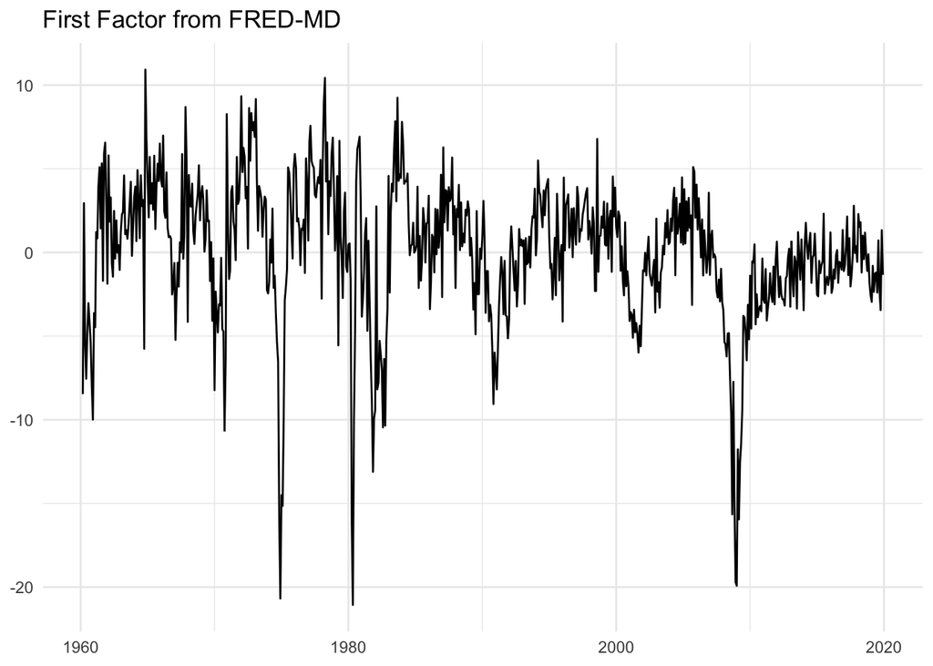

```r
F1 <- pc$x[, 1] * sign(cor(pc$x[, 1], fm$INDPRO))

tibble(date = fm$date, F1 = F1) |>
  ggplot(aes(date, F1)) +
  geom_line() +
  labs(title = "First Factor from FRED-MD", x = NULL, y = NULL) +
  theme_minimal()
```

```r
sort(abs(cor(pc$x[, 1], Z))[1, ], decreasing = TRUE)[1:8]
```

```
   PAYEMS IPMANSICS    USGOOD    INDPRO    MANEMP   IPFPNSS    CUMFNS   DMANEMP
0.8415788 0.8404473 0.8390159 0.8219976 0.8028499 0.7903078 0.7778686 0.7768615
```

```r
sort(abs(cor(pc$x[, 2], Z))[1, ], decreasing = TRUE)[1:8]
```

```
    CUSR0000SAC DNDGRG3M086SBEA   CUSR0000SA0L2        CPIAUCSL   CUSR0000SA0L5
      0.7468587       0.7391330       0.7279202       0.7198020       0.7020307
       CPITRNSL           PCEPI        CPIULFSL
      0.6806883       0.6795890       0.6570361
```

The **first factor** is most correlated with employment, industrial production and capacity utilization (PAYEMS, IPMANSICS, USGOOD, INDPRO, MANEMP, IPFPNSS, CUMFNS, DMANEMP).

The **second factor** is most correlated with CPI and PCE price indexes (such as CPIAUCSL, PCEPI and CPITRNSL), so it is probably an inflation factor.

### 5.3 Replicate the Horse Race from Class

```r
ip <- fm$INDPRO
n <- nrow(Z)
init <- which(fm$date == as.Date("1989-12-01"))

e_ar <- NULL
e_fa <- NULL
for (T in init:(n - 1)) {
  F_T <- prcomp(scale(Z[1:T, ]))$x[, 1:3]         # factors using data through T
  d <- data.frame(y_next = ip[2:T], y = ip[1:(T - 1)], F_T[1:(T - 1), ])
  new <- data.frame(y = ip[T], t(F_T[T, ]))
  e_ar <- c(e_ar, ip[T + 1] - predict(lm(y_next ~ y, d), new))
  e_fa <- c(e_fa, ip[T + 1] - predict(lm(y_next ~ ., d), new))
}

c(RMSE_AR = sqrt(mean(e_ar^2)), RMSE_FA = sqrt(mean(e_fa^2)))
```

```
  RMSE_AR   RMSE_FA
0.6168431 0.5887272
```

I get RMSEs of 0.617 for the AR(1) and 0.589 with the factors, matching class.

Estimating the factors on the full sample would use data from after each forecast origin, which a real forecaster wouldn’t have.

### 5.4 A Direct Forecast of Inflation

```r
direct_race <- function(series, h = 12, r = 3) {
  lv <- md |>
    mutate(log_x = log(.data[[series]]),
           g = 100 * (log_x - lag(log_x))) |>
    filter(date >= as.Date("1960-03-01"), date <= as.Date("2019-12-01"))
  yh <- 100 * (lead(lv$log_x, h) - lv$log_x)   # growth over the next h months
  g  <- lv$g                                   # growth over the latest month

  e_ar <- NULL
  e_fa <- NULL
  for (T in init:(n - h)) {
    F_T <- prcomp(scale(Z[1:T, ]))$x[, 1:r, drop = FALSE]
    i <- 1:(T - h)   # only targets already observed at origin T
    d <- data.frame(yh = yh[i], g = g[i], F_T[i, , drop = FALSE])
    new <- data.frame(g = g[T], F_T[T, , drop = FALSE])
    e_ar <- c(e_ar, yh[T] - predict(lm(yh ~ g, d), new))
    e_fa <- c(e_fa, yh[T] - predict(lm(yh ~ ., d), new))
  }

  tibble(series, forecasts = length(e_ar),
         RMSE_AR = sqrt(mean(e_ar^2)), RMSE_FA = sqrt(mean(e_fa^2)),
         MAE_AR = mean(abs(e_ar)), MAE_FA = mean(abs(e_fa)),
         DM_pvalue = forecast::dm.test(e_ar, e_fa, h = h, power = 2,
                                       varestimator = "bartlett")$p.value)
}

direct_race("CPIAUCSL") |> knitr::kable(digits = 4)
```

| series | forecasts | RMSE_AR | RMSE_FA | MAE_AR | MAE_FA | DM_pvalue |
| --- | --- | --- | --- | --- | --- | --- |
| CPIAUCSL | 349 | 2.1079 | 1.8937 | 1.5777 | 1.3494 | 4e-04 |